# Methods for Data Science M345 A50 Coursework 1 - Machine Learning

Christophe Jefferies

16 November 2018

In this project we work with the dataset ‘druguse’. This is data from over 1800 people about their background, personality traits, and use of both legal and illegal substances.  
We perform exploratory data analysis (EDA), and then use a variety of methods for classifying and interpreting the data. We conclude with a discussion of the quality of these models, what conclusions we can draw from them, and how justified it is to make deductions about the data from them.

# Question 1

### 1.1

Here are two coloured histograms. The first has the predictor ‘country’ on the x-axis, and its bars are coloured by the predictor ‘UseLevel’; the second is the same but with ‘gender’ on the x-axis.

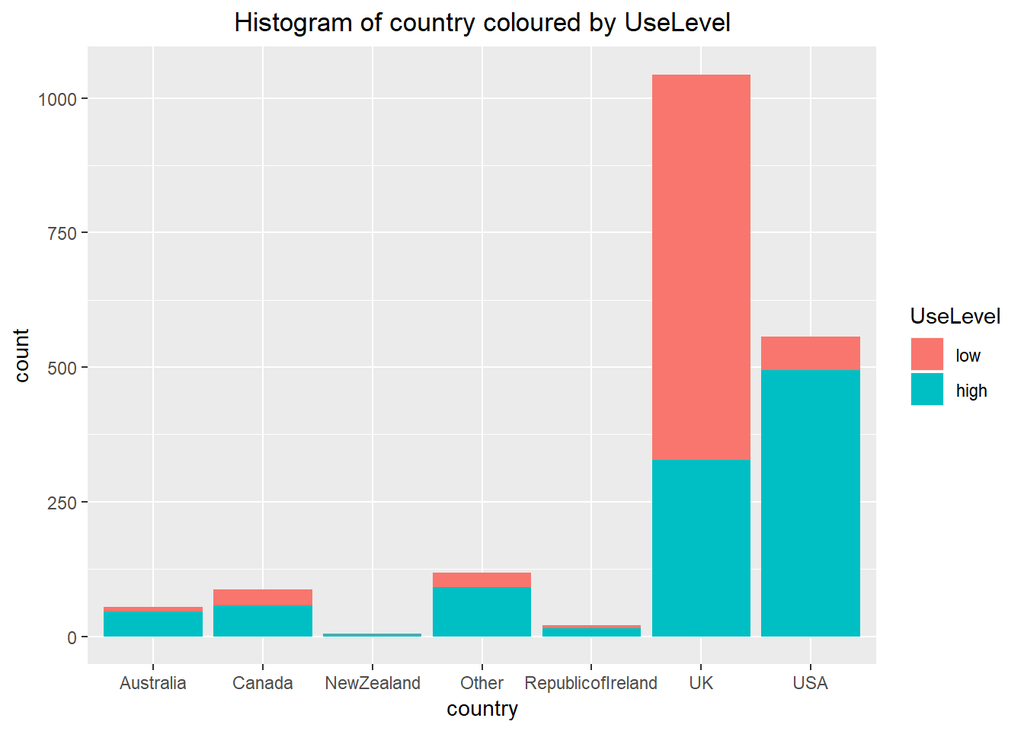

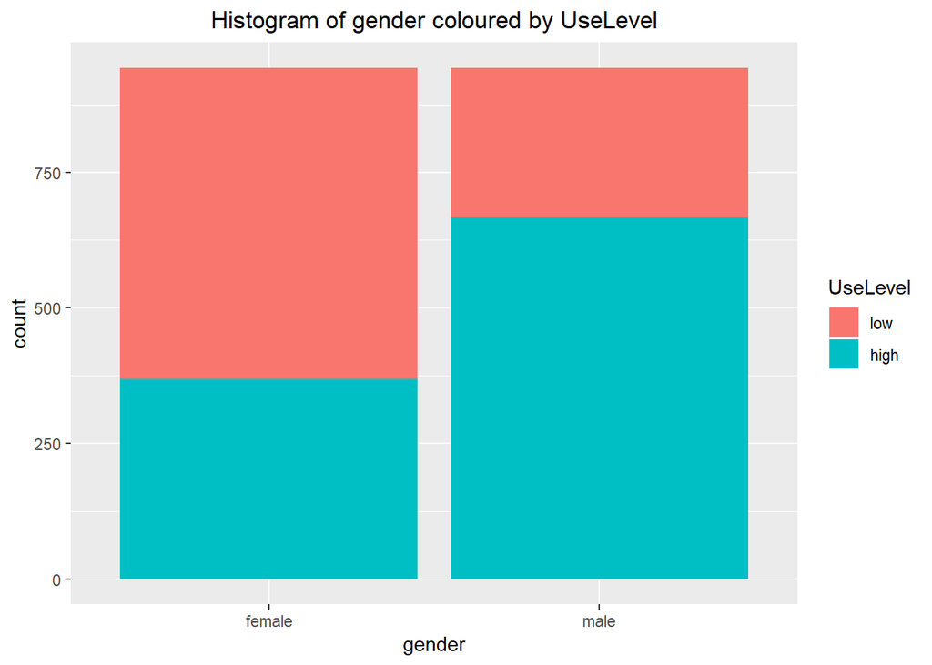

### 1.2

The following plots show some exploratory data analysis (EDA) on the dataset.

TSNE is a powerful non-linear dimensionality reduction algorithm; it works by placing a point in a low-dimensional space for every true data point, then shifting them around to match ‘closeness’ (formally, to minimise a certain divergence between pairs of points and their projections).

Here is a TSNE representation of all the predictors, coloured by UseLevel. Note that the summaries of overall use (any, severity, UseLevel) were not used to create the projection; the clean separation is only a result of the algorithm regarding these points as ‘close’ by some measure.

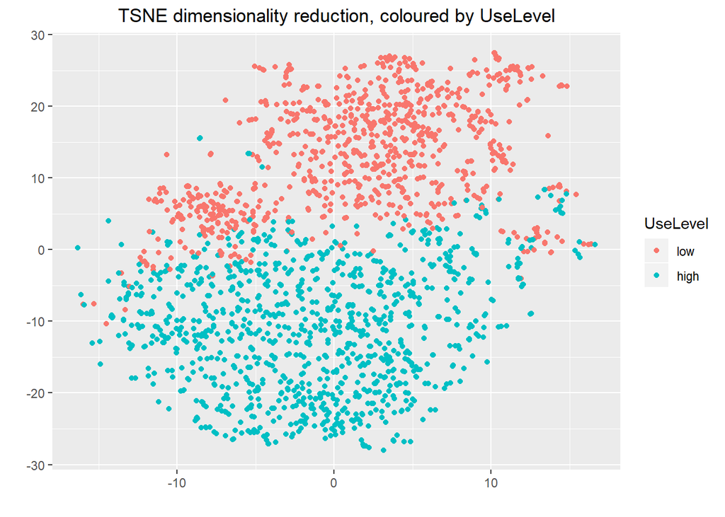

This is a reassuring first sight, as it suggests that we will be able to classify people’s UseLevel based only on the predictors. We could draw a similar conclusion from a PCA projection, but this makes the distinction particularly clear. (Note that labelling the axes in the above figure would not make sense; the projection could be rotated any way around, as all that matters is the closeness of points.)

The following bar chart compares how recently people in the dataset had used legal substances. The usage ratings range from 0 (never used) through 3 (used in last year) to 6 (used in last day).

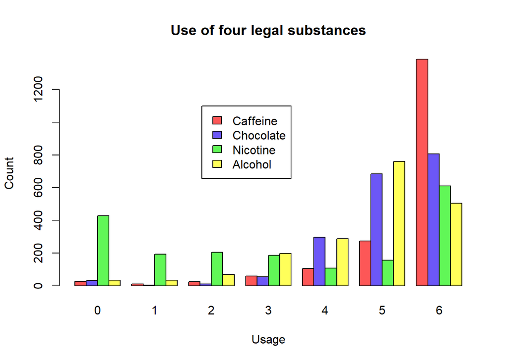

Many people had had drunk coffee in the last day (hence presumably did so on a regular basis). We also see from the green bars that a sizeable portion of people used to smoke but don’t any more.

This is a jitter plot comparing age with different personality traits.

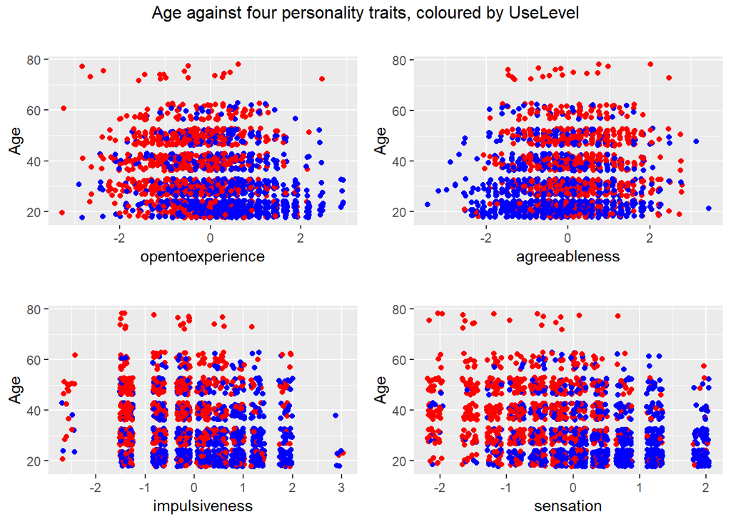

Each of these plots shows a general diagonal shift in colour, representing behavioural changes with age and personality. For instance, young people with a high sensation rating almost exclusively have a high (blue) UseLevel, whilst the opposite is true for oler people with a low sensation rating. Young people with a high UseLevel tend to be less agreeable, but more impulsive and open to experiences.

This next plot compares caffeine and heroin usage with overall illicit substance use (severity).

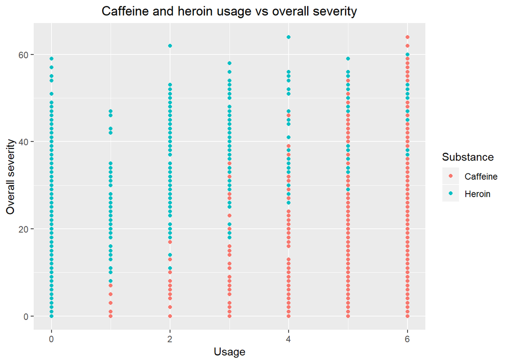

If someone’s caffeine rating is low, then they certainly don’t have a high overall severity rating. Any recent heroin use links with a high overall severity; however there are many people with no heroin use but nonetheless a high severity rating. (This heroin comparison must be taken with a pinch of salt, as ‘severity’ is calculated directly from the illicit substance predictors including heroin.)

The following plot marks what percentage of people from each country had drunk within the last week (a rating greater than 4). We could interpret this as representing the percentage of heavy or frequent drinkers from each country.

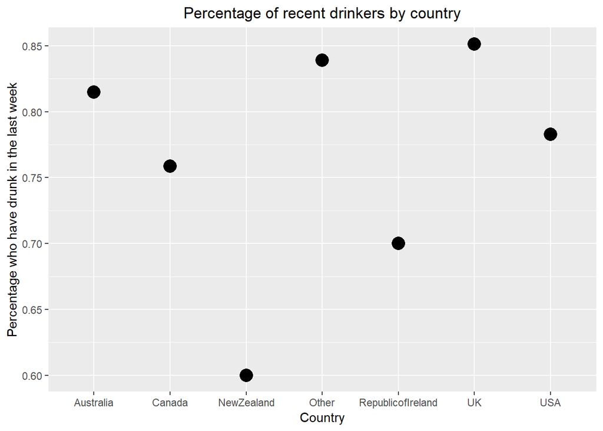

The UK ranks highest here, bu not by much. New Zealand is lowest, though there were only 5 people from there in the whole dataset, so this may not be representative of the actual population.

This final plot gives a picture of enthusiasm for chocolate amongst different countries.

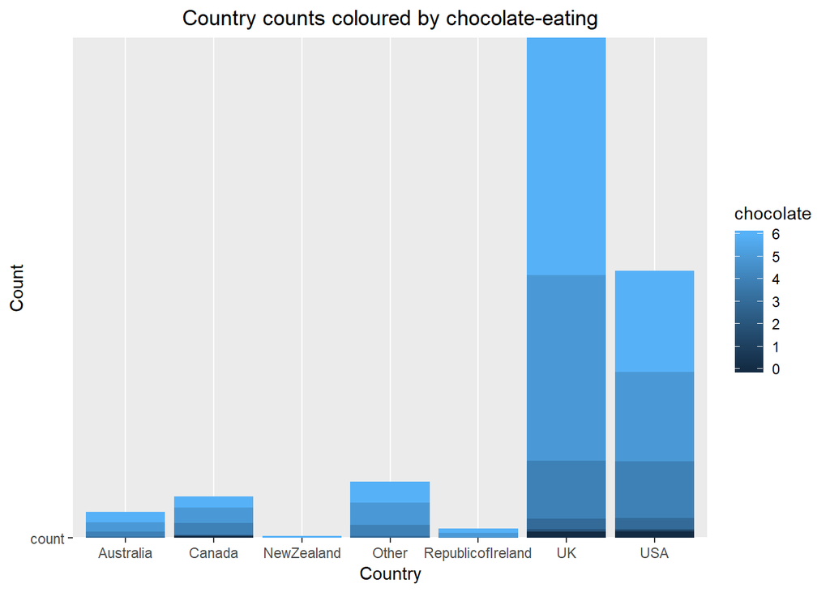

The absolute sizes of the bars here are of little significance; they simply show how well-represented each country was in the sample population. More interesting is the fraction of each colour in every bar: universally, about one third to a half of people had eaten chocolate very recently, and very few people (if any) had never eaten chocolate. (Perhaps this suggests that human beings generally enjoy chocolate…)

# Question 2

In this question we use a logistic regression model to predict UseLevel based on background, personality, and legal substance use. We evaluate the accuracy of the model, analyse the quality of the classifier, and apply some cross-validation.

### 2.1

We first make a dataframe containing only these predictors, and separate training and testing data:

```r
#Ignore the columns we won't use
df = druguse[,-(17:32)]
#Reformat the UseLevel column for correct ROC analysis later
df[[17]] = sapply(as.character(df[[17]]), switch, "low"=0, "high"=1, USE.NAMES = F)
#Separate train data (first 1400 rows) and test data (remaining rows)
drugusetrain = df[1:1400,]
drugusetest = df[-(1:1400),]
```

We then fit a logistic regression model to the training data, and see a summary

```r
model = glm(UseLevel ~., family=binomial(link='logit'), data=drugusetrain)
summary(model)
```

```
##
## Call:
## glm(formula = UseLevel ~ ., family = binomial(link = "logit"),
##     data = drugusetrain)
##
## Deviance Residuals:
##     Min       1Q   Median       3Q      Max
## -3.3880  -0.3865   0.1221   0.4357   2.8387
##
## Coefficients:
##                              Estimate Std. Error z value Pr(>|z|)
## (Intercept)                  -0.84266    1.13278  -0.744  0.45694
## agegroup25-34                 0.26901    0.24571   1.095  0.27359
## agegroup35-44                -0.17433    0.25605  -0.681  0.49598
## agegroup45-54                -0.65564    0.27445  -2.389  0.01690 *
## agegroup55-64                -0.98729    0.40893  -2.414  0.01576 *
## agegroup65+                 -16.81790  502.60332  -0.033  0.97331
## gendermale                    0.93652    0.18530   5.054 4.33e-07 ***
## education                    -0.25677    0.09947  -2.581  0.00984 **
## countryCanada                -0.81196    0.62733  -1.294  0.19556
## countryNewZealand            -0.43152    1.48226  -0.291  0.77096
## countryOther                 -1.00621    0.61469  -1.637  0.10164
## countryRepublicofIreland     -1.61533    0.95965  -1.683  0.09233 .
## countryUK                    -2.10637    0.51748  -4.070 4.69e-05 ***
## countryUSA                    0.07998    0.54650   0.146  0.88364
## ethnicityBlack               -0.46926    1.21613  -0.386  0.69960
## ethnicityMixed-Black/Asian   13.17401 2399.54491   0.005  0.99562
## ethnicityMixed-White/Asian    1.34439    1.34799   0.997  0.31860
## ethnicityMixed-White/Black    0.61315    1.13218   0.542  0.58812
## ethnicityOther                0.41618    0.97087   0.429  0.66816
## ethnicityWhite                1.06211    0.85269   1.246  0.21291
## neuroticism                  -0.06843    0.10697  -0.640  0.52234
## extraversion                 -0.13871    0.11164  -1.242  0.21406
## opentoexperience              0.56631    0.10678   5.304 1.14e-07 ***
## agreeableness                -0.09095    0.09740  -0.934  0.35041
## conscientiousness            -0.31084    0.10487  -2.964  0.00304 **
## impulsiveness                -0.01198    0.11249  -0.107  0.91517
## sensation                     0.72043    0.13213   5.453 4.96e-08 ***
## caffeine                      0.07957    0.08073   0.986  0.32431
## chocolate                    -0.09428    0.08338  -1.131  0.25815
## nicotine                      0.48841    0.03924  12.447  < 2e-16 ***
## alcohol                      -0.06487    0.06890  -0.942  0.34642
## ---
## Signif. codes:  0 '***' 0.001 '**' 0.01 '*' 0.05 '.' 0.1 ' ' 1
##
## (Dispersion parameter for binomial family taken to be 1)
##
##     Null deviance: 1923.39  on 1399  degrees of freedom
## Residual deviance:  894.64  on 1369  degrees of freedom
## AIC: 956.64
##
## Number of Fisher Scoring iterations: 15
```

In particular, a high coefficient for ‘estimate’ represents playing an important role in predicting UseLevel. For instance, nicotine has a fairly high estimate coefficient, so is a good indicator of UseLevel, whilst caffeine is closer to zero and so is less informative. We could conclude that being a smoker means you are more likely to have a high UseLevel, whereas eating chocolate does not necessarily imply this.

The very highest ‘estimate’ coefficient is for ethnicityMixed-Black/Asian, but there only only 3 instances of this predictor class (all with high UseLevels), so in reality this is not very informative. This can also be seen from the huge standard error coefficient, which follows from the tiny sample size.

The meaningful predictors with the highest coefficients are ethnicityMixed-White/Asian, ethnicityWhite, gendermale, and sensation. Of these, gendermale and sensation have an especially small $P(>|z|)$ value; hence deducing that being male and having a high sensation rating are good predictors of UseLevel is statistically justified, and not just an effect of the data’s structure (as was the case for ethnicityMixed-Black/Asian).

### 2.2

We can also use the model to make predictions; we can test the accuracy of predictions on the test data.

```r
#Compute the predicted probability of high UseLevel
pp = predict(model, drugusetest, type="response")
#Choose a threshold (here 0.5) and predict TRUE when above this
mypreds = (pp>0.5)
Trueclasses = (drugusetest$UseLevel==1)
```

This table shows how many of the predictions are correct (TRUE) and incorrect (FALSE)

```
##
## FALSE  TRUE
##    68   417
```

This table separates the classifications into True Positive/Negative and False Positive/Negative.

```
##        Trueclasses
## mypreds FALSE TRUE
##   FALSE   194   35
##   TRUE     33  223
```

### 2.3

The accuracy of the model is

```
## [1] "Accuracy: 0.85979381443299"
```

We can examine the quality of the classifier in more detail with ROC analysis. Rather than choosing one threshold, we can vary it from 0 to 1 and track the True Positive and False Positive rates (TPR, FPR) as this happens.

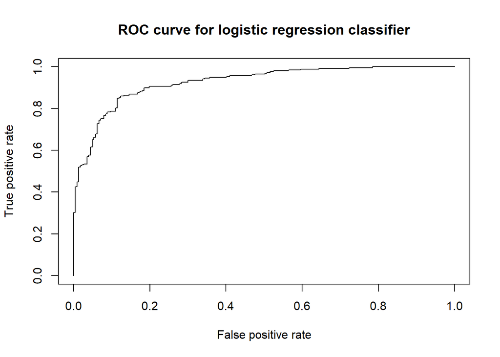

A good indicator of a high-quality classifier is a high area under the ROC curve; this means that for some value of the parameter we are varying, the TPR will be high and the FPR will be low (because the curve always joins bottom left to top right), which is ideal.

```
## [1] "Area under curve: 0.92690298125192"
```

This is a high AUC, so the classifier (with a well-chosen threshold) is of good quality.

### 2.4

The above results might have depended notably on our choice of testing and training data. To see how the classifier might fare against a different dataset, we can use K-folds cross-validation, i.e. repeatedly use different parts of the dataset as test data. Here we use K=10.

```r
K=10 #Number of folds
N=nrow(df) #For more readable code
Accuracies = 0*(1:K) #Store accuracies for each fold

for (i in 1:K){
  #Pick out test indices for this fold
  index = (as.integer((i-1)*N/K)+1):(as.integer(i*N/K))
  #Separate train and test data
  traindata = df[-index,]
  testdata = df[index,]

  #Fit logistic regression model and make predictions
  model = glm(UseLevel ~., family=binomial(link='logit'), data=traindata)
  pp = predict(model, testdata, type="response")

  #Calculate, print, and record the accuracy
  Accuracy = sum((pp>0.5) == (testdata$UseLevel==1))/nrow(testdata)
  print(paste("Test", i, ": Accuracy", Accuracy))
  Accuracies[i] = Accuracy
}
```

```
## [1] "Test 1 : Accuracy 0.803191489361702"
## [1] "Test 2 : Accuracy 0.878306878306878"
## [1] "Test 3 : Accuracy 0.845744680851064"
## [1] "Test 4 : Accuracy 0.862433862433862"
## [1] "Test 5 : Accuracy 0.877659574468085"
## [1] "Test 6 : Accuracy 0.867724867724868"
## [1] "Test 7 : Accuracy 0.861702127659574"
## [1] "Test 8 : Accuracy 0.883597883597884"
## [1] "Test 9 : Accuracy 0.851063829787234"
## [1] "Test 10 : Accuracy 0.835978835978836"
```

```r
paste("Average accuracy is", sum(Accuracies)/10)
```

```
## [1] "Average accuracy is 0.856740403016999"
```

The model is quite consistent across the different folds. We could reasonably expect the about the above average accuracy on a new, similar dataset.

# Question 3

Some predictors are currently factors (which aren’t properly compatible with KNN), so we convert them to numerical values.

```r
#Replace agegroup classes with their midpoints (and 65+ with 70)
df = druguse
df[[1]] = sapply(as.character(df[[1]]), switch, "18-24"=21,"25-34"=29.5,"35-44"=39.5,"45-54"=49.5,"55-64"=59.5,"65+"=70, USE.NAMES = F)

#Replace gender with female = 0, male = 1
df[[2]] = sapply(as.character(df[[2]]), switch, "female"=0, "male"=1, USE.NAMES = F)
```

We ignore the ‘country’ and ‘ethnicity’ predictors as these don’t separate well in to two categories, nor do they map well on to a numerical scale.

```r
df = df[,-c(4, 5, 17:32)] #Ignore country, ethnicity, and the other columns we're not using

#Center and scale the remaining 14 predictor columns ready for KNN
df[,1:14] = scale(df[,1:14], center=TRUE, scale=TRUE)

#Apply K-folds with K=10 (the final accuracy is quite independent of this K)
K=10
N = nrow(df)
Accuracies = 0*(1:K)

for (i in 1:K){
  #Pick out train and test data as before
  index = (as.integer((i-1)*N/K)+1):(as.integer(i*N/K))
  traindata = df[-index,]
  testdata = df[index,]

  #Perform KNN classification and calculate accuracy
  knnpredictions = knn(train=traindata[,-15], test=testdata[,-15], cl=traindata[,15], k=10)
  numbercorrect = sum(knnpredictions==(df$UseLevel[index]))
  print(paste("Fold", i, "Accuracy:", numbercorrect/nrow(testdata)))
  Accuracies[i] = numbercorrect/nrow(testdata)
}
```

```
## [1] "Fold 1 Accuracy: 0.803191489361702"
## [1] "Fold 2 Accuracy: 0.846560846560847"
## [1] "Fold 3 Accuracy: 0.851063829787234"
## [1] "Fold 4 Accuracy: 0.788359788359788"
## [1] "Fold 5 Accuracy: 0.877659574468085"
## [1] "Fold 6 Accuracy: 0.825396825396825"
## [1] "Fold 7 Accuracy: 0.803191489361702"
## [1] "Fold 8 Accuracy: 0.846560846560847"
## [1] "Fold 9 Accuracy: 0.882978723404255"
## [1] "Fold 10 Accuracy: 0.772486772486772"
```

```r
paste("Average accuracy is", sum(Accuracies)/K)
```

```
## [1] "Average accuracy is 0.829745018574806"
```

This is quite a high accuracy for such a simple method. Using K-folds again helps us estimate how the method could perform on observations outside of the training set.

# Question 4

### 4.1

In this part we will use a random forest to predict whether or not someone has ever used heroin. We will use all the background, personality, and legal substance use predictors as before, but will also include the illicit substance predictors.

We will not include the heroin predictor itself, otherwise a single decision tree could perfectly split the data using one branch split; it’s only meaningful to deduce heroin use from the *other* predictors. We also ignore the summary predictors ‘any’, ‘severity’, and ‘UseLevel’ as these are computed directly from illicit drug use.

After setting up the data, we implement a single decision tree just for comparison, and then a full random forest.

```r
#Make a predictor with value "yes" if someone has ever used heroin, else "no"
heroinlogical = (druguse$heroin>0)
usedheroin = sapply(as.character(heroinlogical), switch, "FALSE"="no", "TRUE"="yes", USE.NAMES = F)

#Data and labels
drugusetrain = druguse[1:1400,-c(24, 31:33)] #training data
usedherointrain = usedheroin[1:1400] #training labels
drugusetest = druguse[-(1:1400),-c(24, 31:33)] #test data
usedherointest = usedheroin[-(1:1400)] #test labels

#A single decision tree for comparison: fit model to data and make predictions
set.seed(0)
decisiontree = rpart(usedherointrain ~., method="class", data = drugusetrain)
treepred=predict(decisiontree, newdata = drugusetest,type="class")
table(treepred, usedherointest)
```

```
##         usedherointest
## treepred  no yes
##      no  388  40
##      yes  17  40
```

```r
print(paste("Accuracy:", sum(treepred==usedherointest)/length(usedherointest)))
```

```
## [1] "Accuracy: 0.882474226804124"
```

This is a very high accuracy for a single tree, suggesting that heroin use can be predicted from the other predictors without too much effort. Of course, one tree generally has high variance, and a random forest might improve this further.

```r
#Use logical labels for randomForest
set.seed(0)
randfor = randomForest(heroinlogical[1:1400] ~., data = drugusetrain, importance = TRUE, ntree=200)
#Make predictions, table, and accuracy
forestpred = as.logical(round(predict(randfor, newdata = drugusetest, data = drugusetrain)))
table(forestpred, heroinlogical[-(1:1400)])
```

```
##
## forestpred FALSE TRUE
##      FALSE   398   36
##      TRUE      7   44
```

```r
print(paste("Accuracy:", sum(forestpred==heroinlogical[-(1:1400)])/length(heroinlogical[-(1:1400)])))
```

```
## [1] "Accuracy: 0.911340206185567"
```

The random forest’s accuracy is slightly higher, probably because averaging over more trees inevitably makes the classifier more robust, and because forests usually deal better with high-dimensionality problems than individual trees. However, the difference is not large (even for quite a large number of trees), so perhaps a single tree isn’t so variable for this dataset after all.

### 4.2

Based on my EDA, an interesting problem could be to explore the variety of drugs each person has used. In particular, the question I seek to answer is: which of background, personality, and legal substance use best predicts the total number of illicit drugs someone has ever taken? In addition, how much do individual predictors such as ‘opentoexperience’ ‘sensation’, and ‘education’ affect how many drugs someone has tried?

This can be more clearly motivated by another dimensionality reduction visualisation. If we make a TSNE projection based only on background, personality, and legal substance use, and then colour it by total number of illicit drugs taken, we can certainly see some structure (patches of similar colour, especially for extreme ratings):

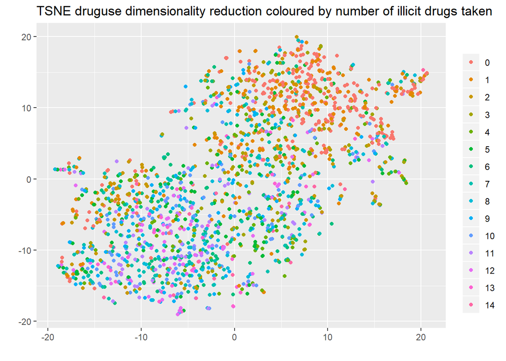

Let’s see how the number of illegal drugs ever used is distributed across the population:

```r
table(numberillegalused)
```

```
## numberillegalused
##   0   1   2   3   4   5   6   7   8   9  10  11  12  13  14
## 299 213 155 105 106 122 128 141 129 126 118  89  88  46  20
```

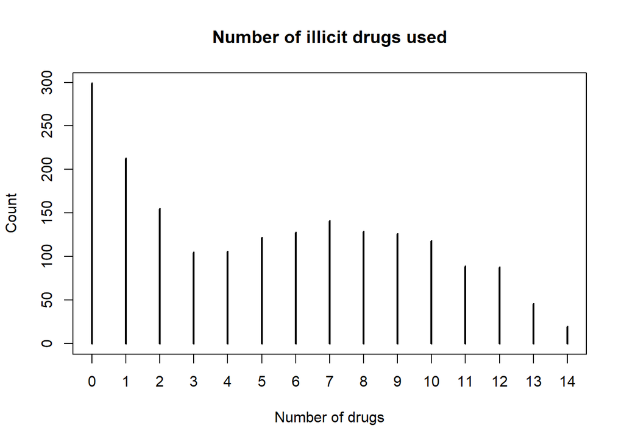

```r
plot(table(numberillegalused), main="Number of illicit drugs used", xlab = "Number of drugs", ylab="Count")
```

We could use a variety of methods to answer the question; however, since we are comparing how different sets of predictors correlate with an outcome, it will be useful to have a quanitifiable measure of this correlation.

Whilst neural networks and support vector machine make good classifiers, they are not so easy to interpret with regards to correlations in the data; for instance, the ‘black box’ of weights and biases in a large neural network gives very little information about why certain predictors might affect certain outcomes.

Therefore I will consciously choose logistic regression, due to its directly interpretable ‘estimation’ coefficients, over these other methods.

This will work best if we split ‘numberillegalused’ in to “low” and “high” as before. From the above plot, where the median lies in the above table, and visual intuition, 5 seems like a good cutoff point.

We now apply logistic regression three times, once for each batch of predictors. The code is similar to before, but with different train and test data and different labels for each of the three groups.

First for all the background predictors:

```
##                testlabels
## backgroundpreds   0   1
##           FALSE 193  87
##           TRUE   60 145
```

```
## [1] "Accuracy is 0.696907216494845"
```

Here is the ROC curve for the classifier:

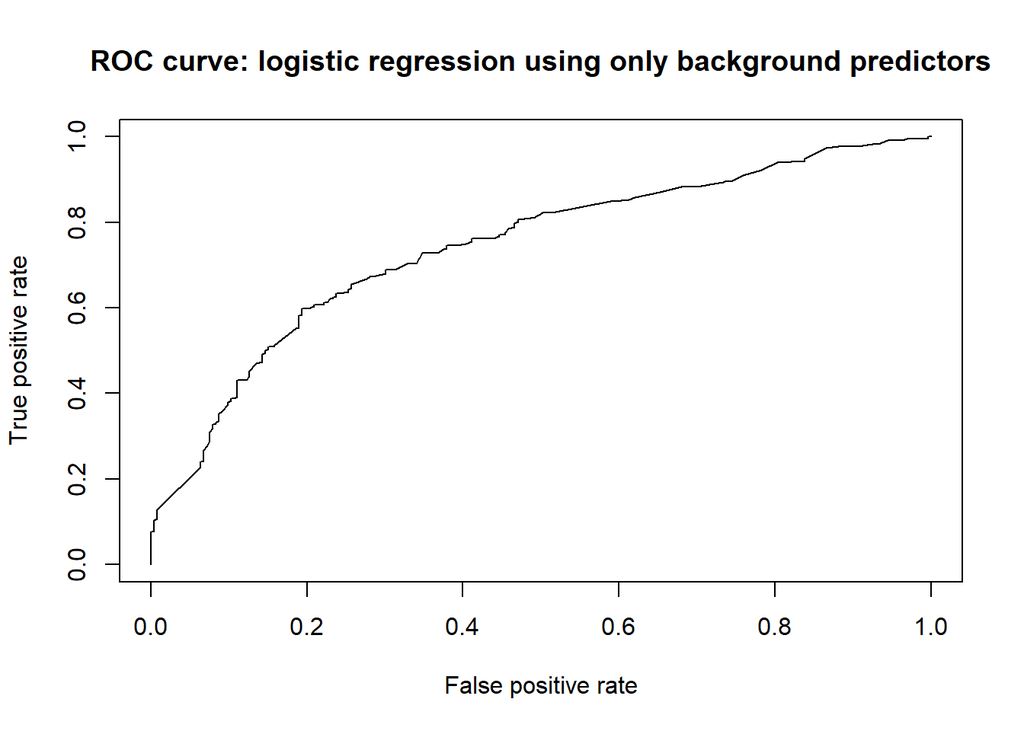

The same for personality:

```
##                 testlabels
## personalitypreds   0   1
##            FALSE 185  91
##            TRUE   68 141
```

```
## [1] "Accuracy is 0.672164948453608"
```

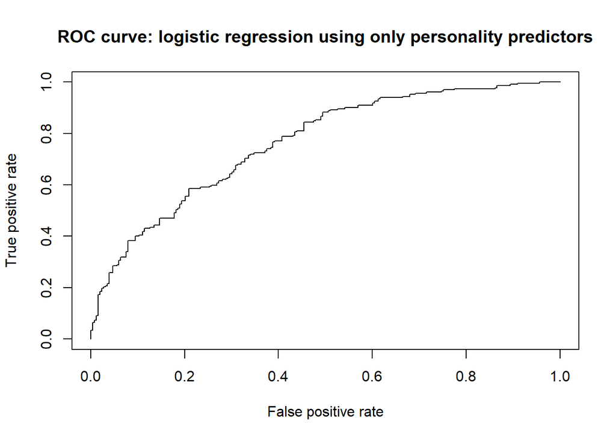

And for legal drug use:

```
##              testlabels
## legalusepreds   0   1
##         FALSE 185  86
##         TRUE   68 146
```

```
## [1] "Accuracy is 0.682474226804124"
```

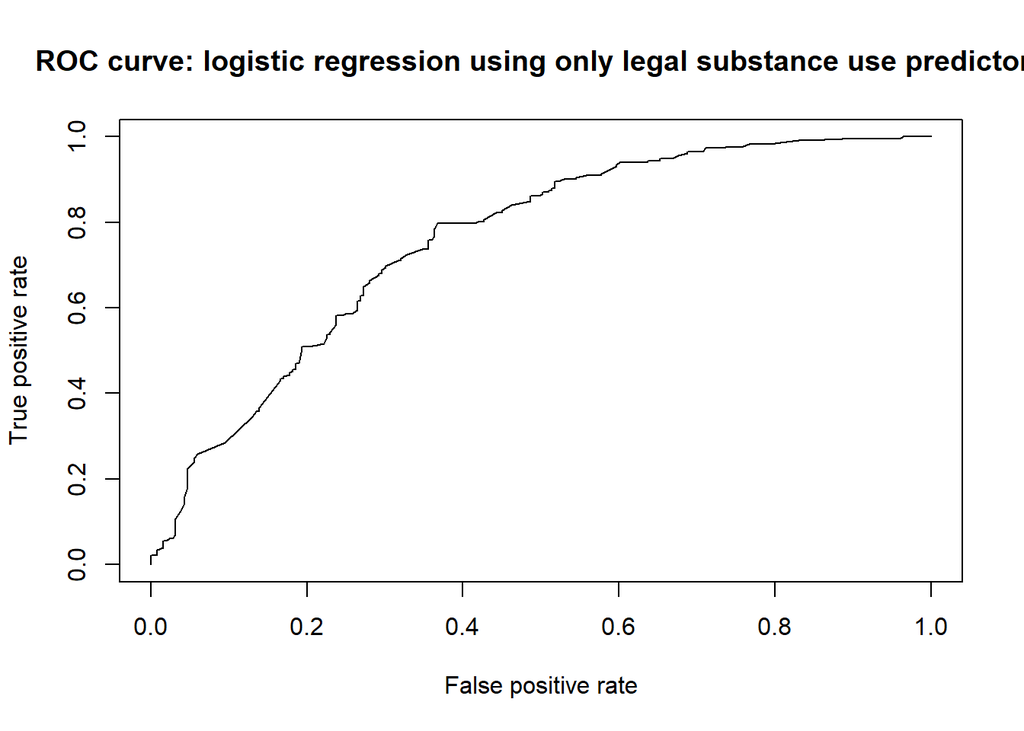

All of these have a reasonable ROC curve and a medium-high accuracy; given that we are using fewer predictors each time, I think it is statistically justified to draw conclusions from the resulting coefficients.

# Question 5

Here are the coefficients for us to interpret:

```
##                (Intercept)              agegroup25-34
##                -1.40609758                 0.57140432
##              agegroup35-44              agegroup45-54
##                 0.28529557                 0.03935659
##              agegroup55-64                agegroup65+
##                -0.27415731                -2.63005380
##                 gendermale                  education
##                 1.13296670                -0.20205777
##              countryCanada          countryNewZealand
##                -0.04528293                -0.64699537
##               countryOther   countryRepublicofIreland
##                 0.20461602                 0.47469427
##                  countryUK                 countryUSA
##                -0.98850433                 0.84884757
##             ethnicityBlack ethnicityMixed-Black/Asian
##                -1.22695750               -12.62103171
## ethnicityMixed-White/Asian ethnicityMixed-White/Black
##                 1.37057132                 0.90237444
##             ethnicityOther             ethnicityWhite
##                 0.68405384                 0.81999259
```

```
##       (Intercept)       neuroticism      extraversion  opentoexperience
##       -0.19842526        0.01712589       -0.27550105        0.56342700
##     agreeableness conscientiousness     impulsiveness         sensation
##       -0.23650987       -0.25782147        0.03188008        0.73809135
```

```
## (Intercept)    caffeine   chocolate    nicotine     alcohol
## -1.10435602  0.05442020 -0.06508641  0.37910757 -0.05533885
```

As one might have guessed, the personality traits that most directly predict variety of drugs ever used are ‘opentoexperience’ and ‘sensation’. The predictors ‘agreeableness’ and ‘conscientiousness’ have fairly large negative coefficient, suggesting that people who are generally more careful and polite tend not to experiment with using different drugs.

The largest coefficient of the background predictors is for ethnicityMixed-White/Asian, though this is anomalous for the same reasons as discussed above. In short, a 25-34 year old white/asian male in America is statistically very likely to have experimented with many drugs (most of these predictors also have a small $P(<|z|)$ value, so this is justified), whilst an uneducated black lady over the age of 65 in the UK is very unlikely to have done so.

As for legal substance use, only nicotine gives any real insight; it weakly positively correlates with having taken a wide variety of drugs before, and the other stubstances barely at all. This could be a consequence of there only being four predictors in this batch, meaning the model has more trouble extrapolating from the data, or it could simply mean that eating chocolate and drinking coffee/alcohol are not good indicators of drug experimentation.